# STAT 420: Homework 09

Fall 2020, D. Unger

Due: Tuesday, November 10 by 11:30 PM CT

# Solution

## Exercise 1 (Writing Functions)

**(a)** Write a function that takes as input a model object (variable) fit via `lm()` and outputs a fitted versus residuals plot. Also, create arguments `pointcol` and `linecol`, which control the point and line colors, respectively. Code the plot to add a horizontal line at $y = 0$, and label the $x$-axis “Fitted” and the $y$-axis “Residuals”.

**Solution:**

```r
plot_fitted_resid = function(model, pointcol = "dodgerblue", linecol = "darkorange") {
  plot(fitted(model), resid(model),
       col = pointcol, pch = 20, cex = 1.5,
       xlab = "Fitted", ylab = "Residuals")
  abline(h = 0, col = linecol, lwd = 2)
}
```

**(b)** Write a function that takes as input a model fit via `lm()` and plots a Normal Q-Q plot of the residuals. Also, create arguments `pointcol` and `linecol`, which control the point and line colors, respectively. Code the plot to add the line from `qqline()`.

**Solution:**

```r
plot_qq = function(model, pointcol = "dodgerblue", linecol = "darkorange") {
  qqnorm(resid(model), col = pointcol, pch = 20, cex = 1.5)
  qqline(resid(model), col = linecol, lwd = 2)
}
```

**(c)** Test your two functions above on the `test_fit` model. For both functions, specify point and line colors that are not black.

```r
set.seed(114)
test_data = data.frame(x = runif(n = 20, min = 0, max = 10),
                       y = rep(x = 0, times = 20))
test_data$y = with(test_data, 5 + 2 * x + rnorm(n = 20))
test_fit = lm(y ~ x, data = test_data)
```

**Solution:**

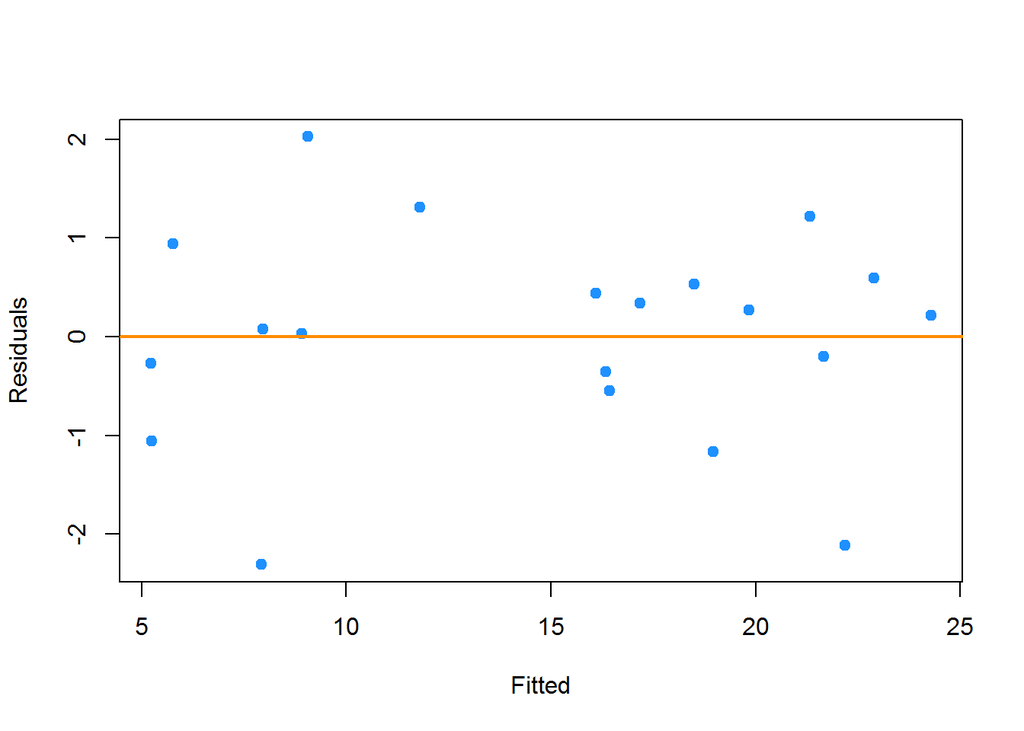

```r
plot_fitted_resid(test_fit)
```

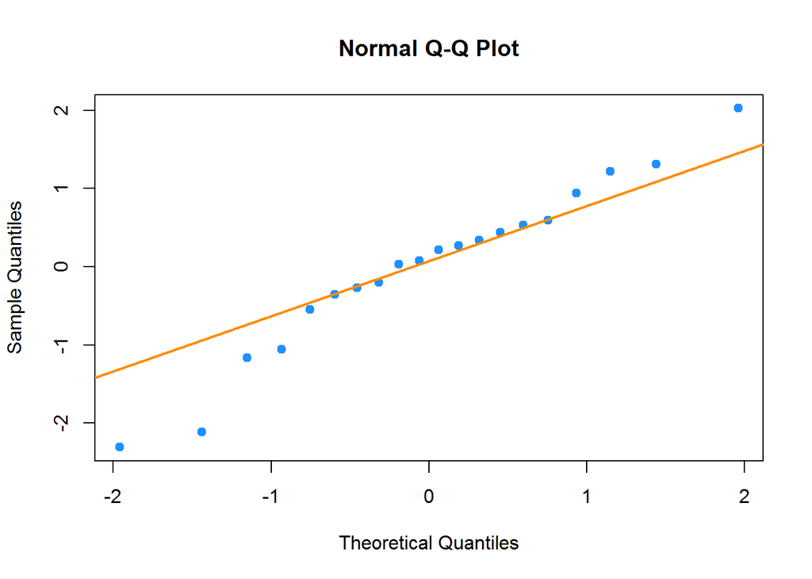

```r
plot_qq(test_fit)
```

## Exercise 2 (Swiss Fertility Data)

For this exercise we will use the `swiss` data, which can be found in the `faraway` package. After loading the `faraway` package, use `?swiss` to learn about this dataset.

```r
library(faraway)
```

**(a)** Fit an additive multiple regression model with `Fertility` as the response and the remaining variables in the `swiss` dataset as predictors. Output the estimated regression coefficients for this model.

**Solution:**

```r
swiss_mod = lm(Fertility ~ ., data = swiss)
coef(swiss_mod)
```

```
##      (Intercept)      Agriculture      Examination        Education
##          66.9152          -0.1721          -0.2580          -0.8709
##         Catholic Infant.Mortality
##           0.1041           1.0770
```

**(b)** Check the constant variance assumption for this model. Do you feel it has been violated? Justify your answer.

**Solution:**

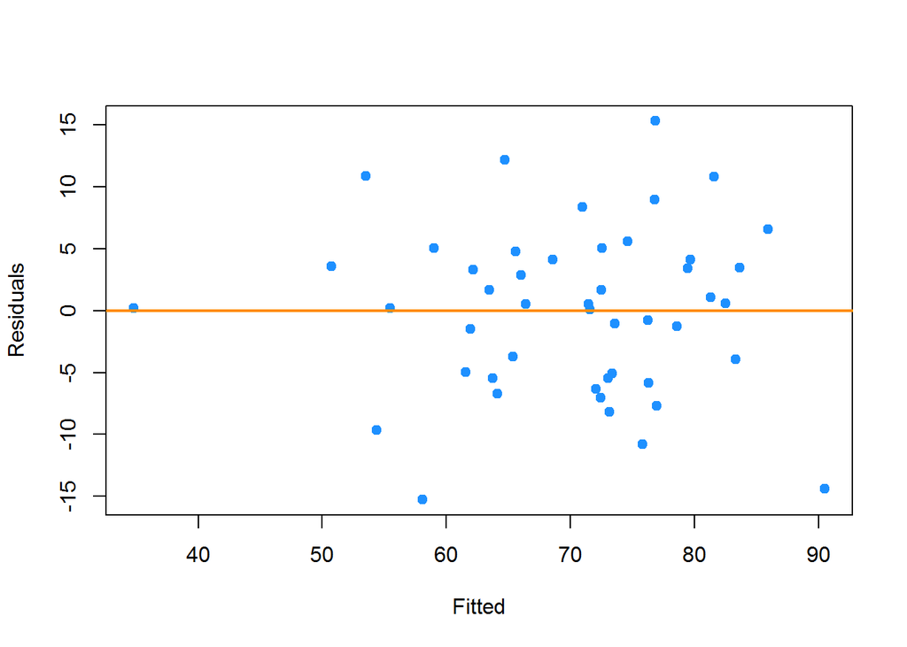

```r
plot_fitted_resid(swiss_mod)
```

```r
library(lmtest)
bptest(swiss_mod)
```

```
##
##  studentized Breusch-Pagan test
##
## data:  swiss_mod
## BP = 5.9, df = 5, p-value = 0.3
```

The fitted versus residuals plot looks pretty good. While we could argue that there is less variance for lower fitted values, there could also simply be less data in that range.

We see the Breuschâ€“Pagan test does not reject, so we choose to believe that the constant variance assumption has not been violated.

**(c)** Check the normality assumption for this model. Do you feel it has been violated? Justify your answer.

**Solution:**

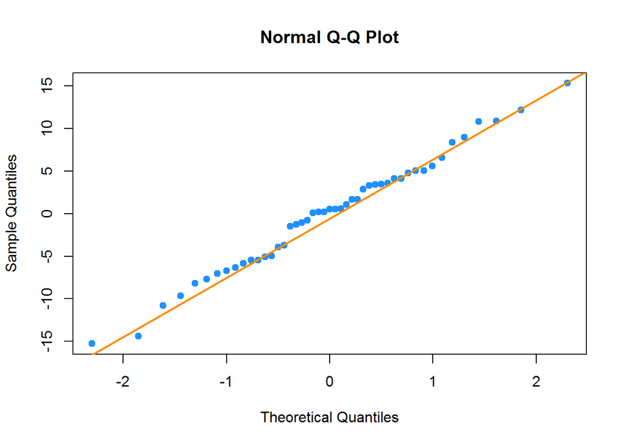

```r
plot_qq(swiss_mod)
```

```r
shapiro.test(resid(swiss_mod))
```

```
##
##  Shapiro-Wilk normality test
##
## data:  resid(swiss_mod)
## W = 0.99, p-value = 0.9
```

The points fall very close to the line in the Q-Q Plot, and the Shapiro-Wilk test does not reject, so we choose to believe that the normality assumption has not been violated.

**(d)** Check for any high leverage observations. Report any observations you determine to have high leverage.

**Solution:**

```r
swiss_mod_lev      = hatvalues(swiss_mod)
swiss_mod_lev_mean = mean(swiss_mod_lev)
swiss_mod_lev[swiss_mod_lev > 2 * swiss_mod_lev_mean]
```

```
##    La Vallee V. De Geneve
##       0.3512       0.4558
```

Based on the heuristic given in the text, we say that the observations “La Vallee V.” and “De Geneve” are points of high leverage. They have greater potential for a large influence on the model fit.

**(e)** Check for any influential observations. Report any observations you determine to be influential.

**Solution:**

```r
swiss_mod_cook = cooks.distance(swiss_mod)
swiss_mod_cook[swiss_mod_cook > 4 / length(swiss_mod_cook)]
```

```
##  Porrentruy      Sierre   Neuchatel Rive Droite Rive Gauche
##      0.2077      0.1476      0.1249      0.1025      0.1124
```

The above observations (with their Cook’s distance reported) are considered influential according to the heuristic given in the text.

**(f)** Refit the additive multiple regression model without any points you identified as influential. Compare the coefficients of this fitted model to the previously fitted model.

**Solution:**

```r
swiss_mod_sub = lm(Fertility ~ ., data = swiss, subset = swiss_mod_cook <= 4 / length(swiss_mod_cook))
(coef(swiss_mod) - coef(swiss_mod_sub)) / coef(swiss_mod)
```

```
##      (Intercept)      Agriculture      Examination        Education
##         0.007033        -0.267754        -0.938558         0.207218
##         Catholic Infant.Mortality
##         0.054241        -0.260550
```

**(g)** Create a data frame that stores the observations that were “removed” because they were influential. Use the two models you have fit to make predictions with these observations. Comment on the difference between these two sets of predictions.

**Solution:**

```r
swiss_removed = swiss[swiss_mod_cook > 4 / length(swiss_mod_cook), ]

predict(swiss_mod, swiss_removed)
```

```
##  Porrentruy      Sierre   Neuchatel Rive Droite Rive Gauche
##       90.50       76.88       53.52       54.36       58.07
```

```r
predict(swiss_mod_sub, swiss_removed)
```

```
##  Porrentruy      Sierre   Neuchatel Rive Droite Rive Gauche
##       94.44       76.34       55.90       57.93       61.32
```

```r
(predict(swiss_mod, swiss_removed) - predict(swiss_mod_sub, swiss_removed)) / predict(swiss_mod, swiss_removed)
```

```
##  Porrentruy      Sierre   Neuchatel Rive Droite Rive Gauche
##   -0.043532    0.007048   -0.044412   -0.065556   -0.055892
```

Compared to the change in the estimated regression coefficients, the change in predicted `Fertility` is rather small. Why could this be? That’s something we will touch on in an upcoming chapter!

## Exercise 3 (Concrete, Again)

Return to the concrete data from the ANOVA homework. Recall, we chose the additive model. Now that we see how ANOVA can be framed as a linear model, check for any violation of assumptions for this model.

**Solution:**

```r
concrete = read.csv("concrete.csv")
concrete$curing = as.factor(concrete$curing)
str(concrete)
```

```
## 'data.frame':    36 obs. of  3 variables:
##  $ curing  : Factor w/ 3 levels "1","2","3": 1 1 1 1 1 1 1 1 1 1 ...
##  $ cement  : chr  "A" "A" "A" "B" ...
##  $ strength: int  14 14 10 6 9 7 22 25 20 10 ...
```

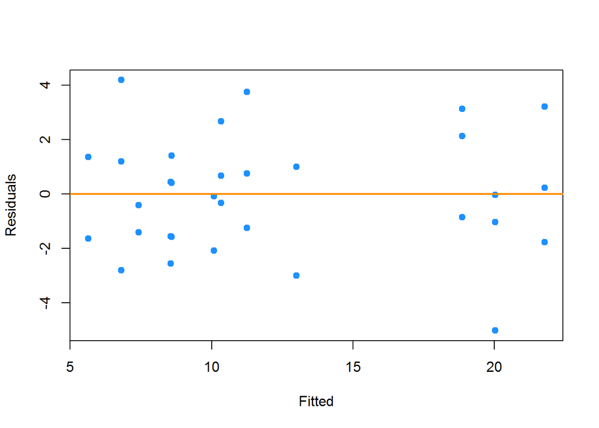

```r
conc_add = aov(strength ~ cement + curing, data = concrete)
plot_fitted_resid(conc_add)
```

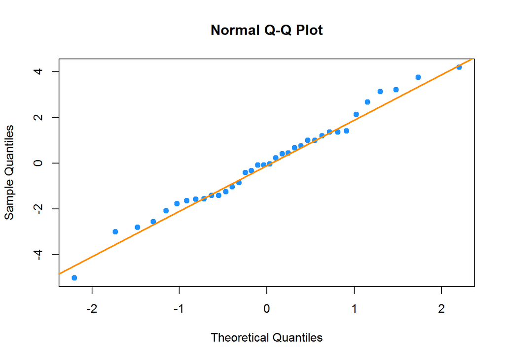

```r
plot_qq(conc_add)
```

```r
conc_add_cook = cooks.distance(conc_add)
conc_add_cook[conc_add_cook > 4 / length(conc_add_cook)]
```

```
##     13     18     20
## 0.1159 0.1450 0.2083
```

Based on the two plots, we identify no violation of assumption. We do note three influential points.

## Exercise 4 (Why Bother?)

**Why** do we care about violations of assumptions? One key reason is that the distributions of the parameters that we have used are all reliant on these assumptions. When the assumptions are violated, the distributional results are not correct, so our tests are garbage. **Garbage In, Garbage Out!**

Consider the following setup that we will use for the remainder of the exercise. We choose a sample size of 50.

```r
n = 50
set.seed(1)
x_1 = runif(n, 0, 10)
x_2 = runif(n, -5, 5)
```

Consider the model,

$$Y = 2 + 1 x_1 + 0 x_2 + \epsilon.$$

That is,

- $\beta_0$ = 2
- $\beta_1$ = 1
- $\beta_2$ = 0

We now simulate `y_1` in a manner that does not violate any assumptions, which we will verify. In this case $\epsilon \sim N(0, 1).$

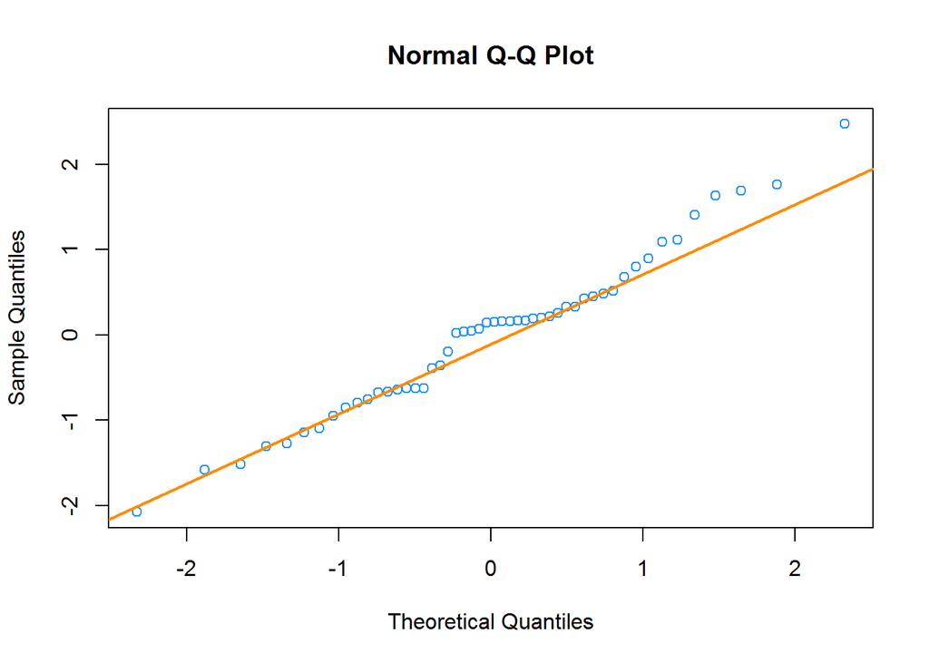

```r
y_1 = 2 + x_1 + 0 * x_2 + rnorm(n = n, mean = 0, sd = 1)
fit_1 = lm(y_1 ~ x_1 + x_2)
qqnorm(resid(fit_1), col = "dodgerblue")
qqline(resid(fit_1), col = "darkorange", lwd = 2)
```

```r
shapiro.test(resid(fit_1))
```

```
##
##  Shapiro-Wilk normality test
##
## data:  resid(fit_1)
## W = 0.98, p-value = 0.6
```

Then, we simulate `y_2` in a manner that **does** violate assumptions, which we again verify. In this case $\epsilon \sim N(0, \sigma = |x_2|).$

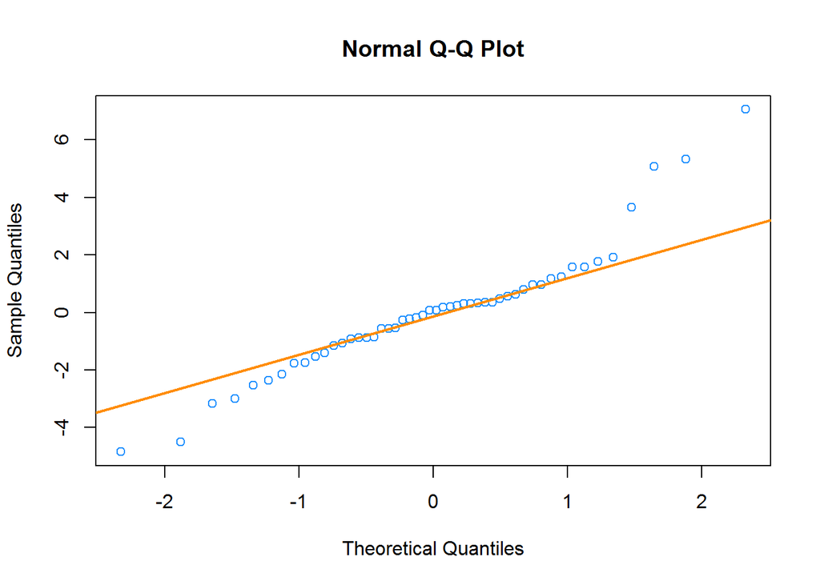

```r
y_2 = 2 + x_1 + 0 * x_2 + rnorm(n = n, mean = 0, sd = abs(x_2))
fit_2 = lm(y_2 ~ x_1 + x_2)
qqnorm(resid(fit_2), col = "dodgerblue")
qqline(resid(fit_2), col = "darkorange", lwd = 2)
```

```r
shapiro.test(resid(fit_2))
```

```
##
##  Shapiro-Wilk normality test
##
## data:  resid(fit_2)
## W = 0.93, p-value = 0.005
```

**(a)** Use the following code after changing `birthday` to your birthday.

```r
num_sims = 1000
p_val_1 = rep(0, num_sims)
p_val_2 = rep(0, num_sims)
birthday = 19081014
set.seed(birthday)
```

Repeat the above process of generating `y_1` and `y_2` as defined above, and fit models with each as the response `1000` times. Each time, store the p-value for testing,

$$\beta_2 = 0,$$

using both models, in the appropriate variables defined above. (You do not need to use a data frame as we have in the past. Although, feel free to modify the code to instead use a data frame.)

**Solution:**

```r
for(i in 1:num_sims) {
  y_1        = 2 + x_1 + 0 * x_2 + rnorm(n)
  fit_1      = lm(y_1 ~ x_1 + x_2)
  p_val_1[i] = summary(fit_1)$coef[3,4]

  y_2        = 2 + x_1 + 0 * x_2 + rnorm(n, 0, abs(x_2))
  fit_2      = lm(y_2 ~ x_1 + x_2)
  p_val_2[i] = summary(fit_2)$coef[3,4]
}
```

**(b)** What proportion of the `p_val_1` values are less than 0.05? Less than 0.10? What proportion of the `p_val_2` values are less than 0.05? Less than 0.10? Briefly explain these results.

**Solution:**

```r
mean(p_val_1 < 0.05)
```

```
## [1] 0.046
```

```r
mean(p_val_1 < 0.10)
```

```
## [1] 0.099
```

```r
mean(p_val_2 < 0.05)
```

```
## [1] 0.144
```

```r
mean(p_val_2 < 0.10)
```

```
## [1] 0.227
```

The results of `p_val_1` are roughly what we would expect. $\beta_2 = 0$ is true in this simulation, so we expect $\alpha$ of these simulations to reject by chance. We see these values are very far off for `p_val_2`, which is a result of the violation of assumptions.